# PCA

Isac

5/1/2020

## Load PCA related packages

```r
library(psych)
library(rela)   # contains Bartlett and KMO tests to verify assumptions
library(MASS)
library(parallel)

options(scipen=999)
```

## Data set

##### Dowload the dataset freely available in the **Support Material** section of https://www.routledge.com/An-Introduction-to-Applied-Multivariate-Analysis/Raykov-Marcoulides/p/book/9780805863758. Under **eResources**, download and unzip the *Data_TF.zip* file and load the data set *ch7ex1.dat*

##### The *S* matrix represents the 5 personality measures for *n=161* subjects

```r
pca <- read.delim(file="ch7ex1.dat", header=TRUE,sep="\t")
colnames(pca) = c("IRLLETT", "FIGREL", "IRSYMB", "CULTFR", "RAVEN")
head(pca)
```

```
##   IRLLETT FIGREL IRSYMB CULTFR  RAVEN
## 1  57.160 73.811 62.876 72.228 66.672
## 2  20.006 38.096 17.148 43.059 38.892
## 3  35.725 69.049 61.447 63.894 61.116
## 4  15.719 30.953 11.432 30.558 16.668
## 5  11.432 42.858 18.577 45.837 22.224
## 6  24.293 61.906 30.009 51.393 44.448
```

```r
tail(pca)
```

```
##     IRLLETT FIGREL IRSYMB CULTFR  RAVEN
## 156  42.870 64.287 55.731 58.338 72.228
## 157  30.009 50.001 40.012 45.837 55.560
## 158  27.151 50.001 37.154 52.782 44.448
## 159  52.873 57.144 57.160 68.061 66.672
## 160  47.157 57.144 62.876 61.116 44.448
## 161  40.012 59.525 48.586 55.560 50.004
```

##### Compute the correlation matrix (notice that the diagonal is obviously all 1’s)

```r
pcacor <- cor(pca)
pcacor
```

```
##           IRLLETT    FIGREL    IRSYMB    CULTFR     RAVEN
## IRLLETT 1.0000000 0.6506553 0.8532134 0.6812657 0.6158707
## FIGREL  0.6506553 1.0000000 0.7185869 0.7613804 0.6357581
## IRSYMB  0.8532134 0.7185869 1.0000000 0.7652237 0.6762137
## CULTFR  0.6812657 0.7613804 0.7652237 1.0000000 0.6389802
## RAVEN   0.6158707 0.6357581 0.6762137 0.6389802 1.0000000
```

##### Compute the variance-covariance matrix

```r
pcacov <- cov(pca)
pcacov
```

```
##          IRLLETT   FIGREL   IRSYMB   CULTFR    RAVEN
## IRLLETT 218.0572 155.1517 220.9215 127.0058 183.4952
## FIGREL  155.1517 260.7598 203.4674 155.2186 207.1391
## IRSYMB  220.9215 203.4674 307.4611 169.3969 239.2373
## CULTFR  127.0058 155.2186 169.3969 159.3836 162.7643
## RAVEN   183.4952 207.1391 239.2373 162.7643 407.0987
```

##### Check the statistical significance of the bivariate correlation using the *psych* package and *corr.p()* function

```r
statSig <- corr.p(pcacor, 161, alpha=.05)
print(statSig, short=FALSE)
```

```
## Call:corr.p(r = pcacor, n = 161, alpha = 0.05)
## Correlation matrix
##         IRLLETT FIGREL IRSYMB CULTFR RAVEN
## IRLLETT    1.00   0.65   0.85   0.68  0.62
## FIGREL     0.65   1.00   0.72   0.76  0.64
## IRSYMB     0.85   0.72   1.00   0.77  0.68
## CULTFR     0.68   0.76   0.77   1.00  0.64
## RAVEN      0.62   0.64   0.68   0.64  1.00
## Sample Size
## [1] 161
## Probability values (Entries above the diagonal are adjusted for multiple tests.)
##         IRLLETT FIGREL IRSYMB CULTFR RAVEN
## IRLLETT       0      0      0      0     0
## FIGREL        0      0      0      0     0
## IRSYMB        0      0      0      0     0
## CULTFR        0      0      0      0     0
## RAVEN         0      0      0      0     0
##
##  Confidence intervals based upon normal theory.  To get bootstrapped values, try cor.ci
##             lower    r upper p
## IRLLE-FIGRE  0.55 0.65  0.73 0
## IRLLE-IRSYM  0.80 0.85  0.89 0
## IRLLE-CULTF  0.59 0.68  0.76 0
## IRLLE-RAVEN  0.51 0.62  0.70 0
## FIGRE-IRSYM  0.63 0.72  0.79 0
## FIGRE-CULTF  0.69 0.76  0.82 0
## FIGRE-RAVEN  0.53 0.64  0.72 0
## IRSYM-CULTF  0.69 0.77  0.82 0
## IRSYM-RAVEN  0.58 0.68  0.75 0
## CULTF-RAVEN  0.54 0.64  0.72 0
```

## Verify assumptions

##### This is an essential step, otherwise we cannot perform the PCA. Verify the 3 assumptions:

1. Sphericity *(Bartlett Test of Sphericity for covariance matrices)*
2. Sample Adequacy *(Kaiser-Meyer-Olkin Measure of sampling adequacy test)*
3. Positive determinant of the matrix *(det() function)*

#### Test assumptions 1 and 2

```r
# the paf() function calculates both Bartlett and KMO tests

# coerce data into a matrix and ignore headers
dat <- data.matrix(pca[1:5])
paf.pca <- paf(dat, eigcrit=1, convcrit=.001)
summary(paf.pca)  # Notice Bartlett and KMO values and ignore the rest
```

```
## $KMO
## [1] 0.85876
##
## $MSA
##             MSA
## IRLLETT 0.82285
## FIGREL  0.88671
## IRSYMB  0.80211
## CULTFR  0.87593
## RAVEN   0.94344
##
## $Bartlett
## [1] 614.15
##
## $Communalities
##         Initial Communalities Final Extraction
## IRLLETT               0.73264          0.70657
## FIGREL                0.64069          0.67328
## IRSYMB                0.80606          0.85510
## CULTFR                0.68467          0.72786
## RAVEN                 0.51579          0.55627
##
## $Factor.Loadings
##            [,1]
## IRLLETT 0.84058
## FIGREL  0.82054
## IRSYMB  0.92472
## CULTFR  0.85315
## RAVEN   0.74583
##
## $RMS
## [1] 0.039232
```

##### Since KMO = 0.86 (i.e. close to 1), the data set with *n=161* and *5* variables, is an adequate sample size

##### Bartlett chi-square = 614.15 does not show a *p* value. We must thus compute the statistical seignificance:

```r
#Bartlett significance test using correlation matrix

cortest.bartlett(pcacor, n=161)
```

```
## $chisq
## [1] 614.15
##
## $p.value
## [1] 0.00000000000000000000000000000000000000000000000000000000000000000000000000000000000000000000000000000000000000000000000000001638
##
## $df
## [1] 10
```

##### With *df=10* and *p<.00001* the statistical significance has been established

#### Test assumption 3

```r
# Verify that the determinant is positive

det(pcacor)
```

```
## [1] 0.020255
```

##### Since the determinant is positive (0.020255) we completed the assumptions tests and can proceed with performing PCA

## Complete PCA

##### Number of Components using the **principal()** function

```r
pca1Component <- principal(pcacor, rotate="none")    # default with 1 component and no scores

pca1Component
```

```
## Principal Components Analysis
## Call: principal(r = pcacor, rotate = "none")
## Standardized loadings (pattern matrix) based upon correlation matrix
##          PC1   h2   u2 com
## IRLLETT 0.87 0.76 0.24   1
## FIGREL  0.86 0.75 0.25   1
## IRSYMB  0.92 0.85 0.15   1
## CULTFR  0.88 0.78 0.22   1
## RAVEN   0.81 0.66 0.34   1
##
##                 PC1
## SS loadings    3.80
## Proportion Var 0.76
##
## Mean item complexity =  1
## Test of the hypothesis that 1 component is sufficient.
##
## The root mean square of the residuals (RMSR) is  0.07
##
## Fit based upon off diagonal values = 0.99
```

```r
pca5Components <- principal(pcacor, nfactors=5, rotate="none")   #we calculate all 5 components

pca5Components
```

```
## Principal Components Analysis
## Call: principal(r = pcacor, nfactors = 5, rotate = "none")
## Standardized loadings (pattern matrix) based upon correlation matrix
##          PC1   PC2   PC3   PC4   PC5 h2                  u2 com
## IRLLETT 0.87 -0.39  0.17  0.08  0.21  1 0.00000000000000011 1.6
## FIGREL  0.86  0.19 -0.35  0.32  0.00  1 0.00000000000000289 1.7
## IRSYMB  0.92 -0.24  0.08 -0.02 -0.29  1 0.00000000000000200 1.4
## CULTFR  0.88  0.07 -0.28 -0.36  0.07  1 0.00000000000000178 1.6
## RAVEN   0.81  0.42  0.41 -0.01  0.02  1 0.00000000000000211 2.0
##
##                        PC1  PC2  PC3  PC4  PC5
## SS loadings           3.80 0.43 0.40 0.24 0.13
## Proportion Var        0.76 0.09 0.08 0.05 0.03
## Cumulative Var        0.76 0.85 0.93 0.97 1.00
## Proportion Explained  0.76 0.09 0.08 0.05 0.03
## Cumulative Proportion 0.76 0.85 0.93 0.97 1.00
##
## Mean item complexity =  1.7
## Test of the hypothesis that 5 components are sufficient.
##
## The root mean square of the residuals (RMSR) is  0
##
## Fit based upon off diagonal values = 1
```

##### The eigenvalues of the components are:

1. PC1 = 3.8 (76%)
2. PC2 = .43 (9%)
3. PC3 = .40 (8%)
4. PC4 = .24 (5%)
5. PC5 = .13 (3%)

##### You can decide which variables you want to keep and what percentage of the variance you are satisfied with explaining (they add up to 100%)

##### Finally, we need to be mindful of the residual error (even if small). We can use the *Cronbach alpha reliability coefficient* for assessing the internal consistency. Notice that *alpha=.92*. i.e. no impact on the PCA results

```r
alpha(pcacor)
```

```
##
## Reliability analysis
## Call: alpha(x = pcacor)
##
##   raw_alpha std.alpha G6(smc) average_r S/N median_r
##       0.92      0.92    0.91       0.7  12     0.68
##
##     95% confidence boundaries
##       lower alpha upper
## Feldt  0.71  0.92  0.99
##
##  Reliability if an item is dropped:
##         raw_alpha std.alpha G6(smc) average_r  S/N  var.r med.r
## IRLLETT      0.90      0.90    0.88      0.70  9.3 0.0034  0.70
## FIGREL       0.91      0.91    0.89      0.71  9.6 0.0079  0.68
## IRSYMB       0.89      0.89    0.86      0.66  7.9 0.0027  0.64
## CULTFR       0.90      0.90    0.89      0.69  9.0 0.0075  0.66
## RAVEN        0.92      0.92    0.91      0.74 11.3 0.0052  0.74
##
##  Item statistics
##            r r.cor r.drop
## IRLLETT 0.87  0.85   0.80
## FIGREL  0.86  0.82   0.78
## IRSYMB  0.92  0.92   0.87
## CULTFR  0.88  0.85   0.81
## RAVEN   0.82  0.74   0.72
```

#### Scree Plot

##### The above computations are typically sufficient to help us decide how many *principal components* to keep and avoid diminishing return. The *Scree Plot* provides additional visualization to help with that decision. **Main idea:** select eigenvalues > 1.0

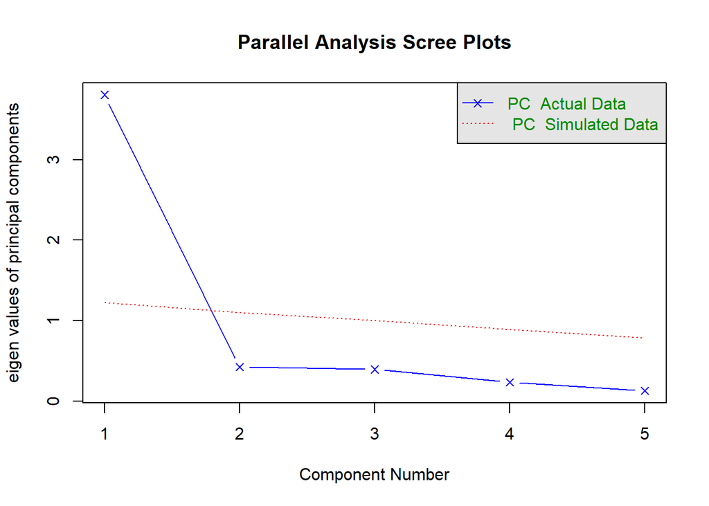

```
## Parallel analysis suggests that the number of factors =  NA  and the number of components =  1
```

```r
fa.parallel(pca,n.obs=161, fm="pa", fa="pc")
```

##### Plot the component structure of the PCA model with 5 components

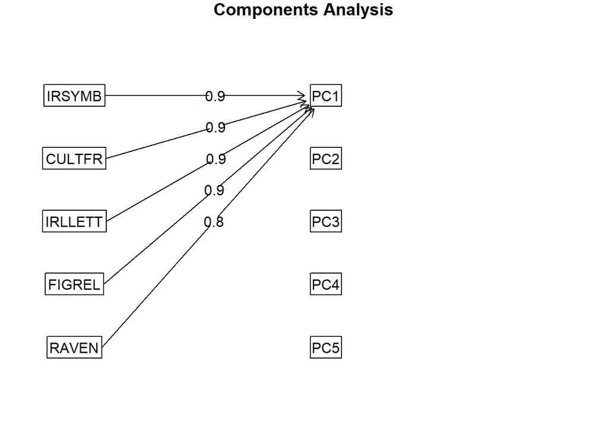

```r
fa.diagram(pca5Components)
```

##### It is clear that one component yields 76% of the variance and explains all 5 variables. We can now compute the principal component using the first set of weights

```r
pcaDF <- data.frame(pca)   # convert pca matrix to dataframe
attach(pcaDF)              # so we can use variable names

pcscores <- .87*IRLLETT + .86*FIGREL + .92*IRSYMB + .88*CULTFR + .81*RAVEN
pcscores <- sort(pcscores, decreasing=FALSE)

pcscores
```

```
##   [1]  66.213  68.637  72.503  76.810  78.953  79.551  84.867  87.248  89.191
##  [10]  89.709  89.991  90.550  91.205  95.636  96.006 104.952 105.258 107.413
##  [19] 107.830 108.742 109.930 109.967 110.924 113.393 113.514 116.469 117.148
##  [28] 117.347 118.309 118.697 119.498 120.276 121.047 122.097 122.233 122.366
##  [37] 126.032 127.904 129.690 129.967 130.087 130.378 130.877 131.183 132.103
##  [46] 132.916 134.013 135.338 137.440 139.057 139.215 139.842 140.661 140.929
##  [55] 141.955 144.532 145.171 147.253 147.606 148.133 148.303 148.620 149.132
##  [64] 149.196 149.239 149.481 149.523 149.746 150.122 151.098 151.901 152.478
##  [73] 152.803 154.594 156.700 157.472 158.693 163.247 163.804 164.015 165.270
##  [82] 165.957 167.372 170.332 173.946 174.577 175.472 177.328 179.502 180.581
##  [91] 183.193 183.211 183.255 183.743 188.457 188.846 190.460 190.623 191.260
## [100] 192.115 194.793 195.040 195.100 195.850 196.558 198.746 200.038 206.094
## [109] 207.970 209.585 210.206 210.906 212.438 215.468 216.833 218.474 219.792
## [118] 220.097 223.823 224.826 225.808 226.536 226.862 227.245 234.470 235.851
## [127] 237.801 238.369 238.440 239.741 243.945 244.612 246.372 246.485 247.534
## [136] 247.931 248.449 249.320 249.965 252.725 253.698 255.213 257.898 258.235
## [145] 258.359 261.629 263.630 263.670 264.505 267.520 272.076 274.278 284.499
## [154] 288.618 292.097 292.268 292.303 307.252 310.589 317.850 329.275
```

##### s = 100/(max - (-min)) = 100/(329.275 - (-66.213)) = .25285

```r
pcscaled <- 16.742 + (.25285 * pcscores)
round(pcscaled,2)
```

```
##   [1]  33.48  34.10  35.07  36.16  36.71  36.86  38.20  38.80  39.29  39.42
##  [11]  39.50  39.64  39.80  40.92  41.02  43.28  43.36  43.90  44.01  44.24
##  [21]  44.54  44.55  44.79  45.41  45.44  46.19  46.36  46.41  46.66  46.75
##  [31]  46.96  47.15  47.35  47.61  47.65  47.68  48.61  49.08  49.53  49.60
##  [41]  49.63  49.71  49.83  49.91  50.14  50.35  50.63  50.96  51.49  51.90
##  [51]  51.94  52.10  52.31  52.38  52.64  53.29  53.45  53.97  54.06  54.20
##  [61]  54.24  54.32  54.45  54.47  54.48  54.54  54.55  54.61  54.70  54.95
##  [71]  55.15  55.30  55.38  55.83  56.36  56.56  56.87  58.02  58.16  58.21
##  [81]  58.53  58.70  59.06  59.81  60.72  60.88  61.11  61.58  62.13  62.40
##  [91]  63.06  63.07  63.08  63.20  64.39  64.49  64.90  64.94  65.10  65.32
## [101]  66.00  66.06  66.07  66.26  66.44  66.99  67.32  68.85  69.33  69.74
## [111]  69.89  70.07  70.46  71.22  71.57  71.98  72.32  72.39  73.34  73.59
## [121]  73.84  74.02  74.10  74.20  76.03  76.38  76.87  77.01  77.03  77.36
## [131]  78.42  78.59  79.04  79.07  79.33  79.43  79.56  79.78  79.95  80.64
## [141]  80.89  81.27  81.95  82.04  82.07  82.89  83.40  83.41  83.62  84.38
## [151]  85.54  86.09  88.68  89.72  90.60  90.64  90.65  94.43  95.27  97.11
## [161] 100.00
```

### Plot Histogram

##### Show equivalency of principal component scores and scaled scores

##### Instead of 5 variables, we need only use one. We can easily choose 50 as the threshold for assessing who is above or below average.

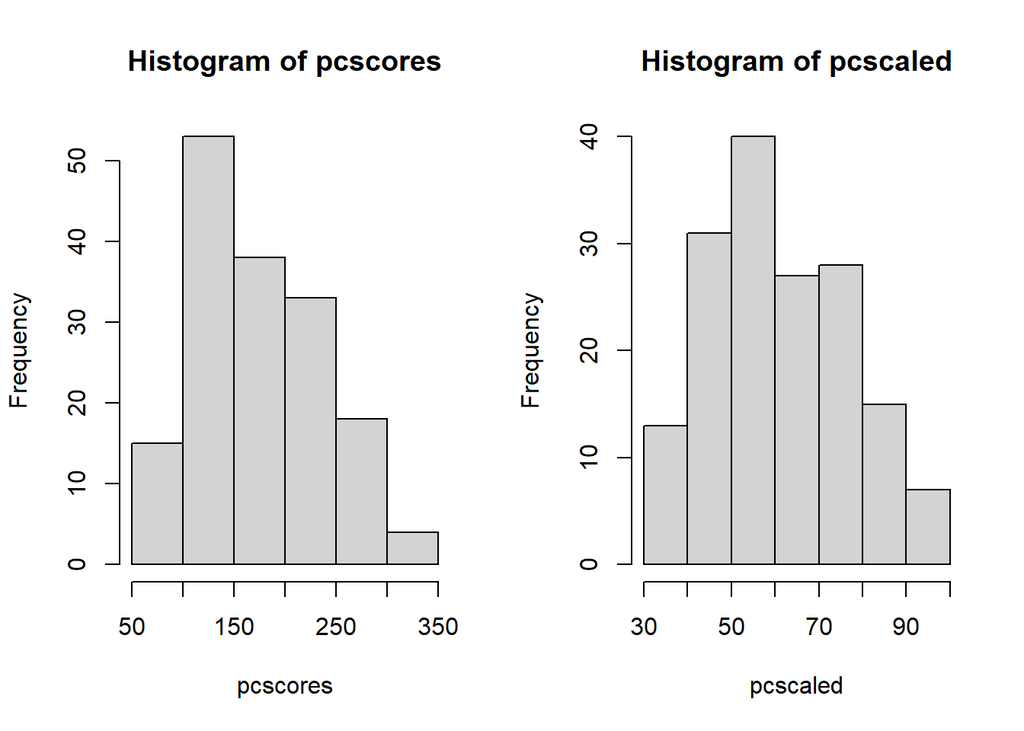

```r
par(mfrow = c(1,2))

hist(pcscores)
hist(pcscaled)
```

### Final report

##### Note: this is a summary. Your reports should be more substantial :)

1. PCA was performed with 5 variables: IRLETT, FIGREL, IRSYMB, CULTFR, RAVEN
2. Statistically significant bivariations were found
3. The three assumptions were successfully tested: sphericity, sample adequacy, positive determinant
4. PCA revealed one variable explained 76% of the variance (review table above and Cronbach’s alpha)